# updated assignmnet 4

Sachini

2025-10-03

# part 01: Gene expression

```r
# Q1: inspect first 6 rows and structure
head(expr)
```

```
##                               GTEX.1117F.0226.SM.5GZZ7 GTEX.1117F.0426.SM.5EGHI
## ENSG00000223972.5_DDX11L1                            0                        0
## ENSG00000227232.5_WASH7P                           187                      109
## ENSG00000278267.1_MIR6859-1                          0                        0
## ENSG00000243485.5_MIR1302-2HG                        1                        0
## ENSG00000237613.2_FAM138A                            0                        0
## ENSG00000268020.3_OR4G4P                             0                        1
##                               GTEX.1117F.0526.SM.5EGHJ
## ENSG00000223972.5_DDX11L1                            0
## ENSG00000227232.5_WASH7P                           143
## ENSG00000278267.1_MIR6859-1                          1
## ENSG00000243485.5_MIR1302-2HG                        0
## ENSG00000237613.2_FAM138A                            0
## ENSG00000268020.3_OR4G4P                             0
```

```r
str(expr)
```

```
## 'data.frame':    56200 obs. of  3 variables:
##  $ GTEX.1117F.0226.SM.5GZZ7: int  0 187 0 1 0 0 1 0 0 2 ...
##  $ GTEX.1117F.0426.SM.5EGHI: int  0 109 0 0 0 1 1 2 2 1 ...
##  $ GTEX.1117F.0526.SM.5EGHJ: int  0 143 1 0 0 0 0 1 3 0 ...
```

To make sure the gene IDs became the row names, I used read.table() to import the gene_expression.tsv file with row.names = 1. I then used head(expr) to display the dataset’s top six rows. The answer is, The dataset includes three samples (columns) with 56,200 genes (rows). The RNA-seq count values for the first six genes are displayed in the table.

```r
# Q2: add a row-wise mean of all expression columns
expr$mean <- rowMeans(expr, na.rm = TRUE)
head(expr)
```

```
##                               GTEX.1117F.0226.SM.5GZZ7 GTEX.1117F.0426.SM.5EGHI
## ENSG00000223972.5_DDX11L1                            0                        0
## ENSG00000227232.5_WASH7P                           187                      109
## ENSG00000278267.1_MIR6859-1                          0                        0
## ENSG00000243485.5_MIR1302-2HG                        1                        0
## ENSG00000237613.2_FAM138A                            0                        0
## ENSG00000268020.3_OR4G4P                             0                        1
##                               GTEX.1117F.0526.SM.5EGHJ        mean
## ENSG00000223972.5_DDX11L1                            0   0.0000000
## ENSG00000227232.5_WASH7P                           143 146.3333333
## ENSG00000278267.1_MIR6859-1                          1   0.3333333
## ENSG00000243485.5_MIR1302-2HG                        0   0.3333333
## ENSG00000237613.2_FAM138A                            0   0.0000000
## ENSG00000268020.3_OR4G4P                             0   0.3333333
```

I used rowMeans(expr) to get each gene’s mean expression across the three samples. The dataset now includes this additional vector as a new column named expr$mean. I then showed this changed table’s first six rows.The answer is, In order to summarise the average expression of each gene across samples, a new column mean was successfully introduced.

```r
 #  Q3 — list the 10 genes with highest mean
# ensure the mean exists
stopifnot("mean" %in% colnames(expr))

# order genes by mean (highest first)
ord <- order(expr$mean, decreasing = TRUE, na.last = NA)

# take up to the first 10 indices (handles datasets with <10 rows too)
top_idx <- head(ord, 10)

# build the table using row names as gene IDs
top_table <- data.frame(
  Gene = rownames(expr)[top_idx],
  Mean = expr$mean[top_idx],
  row.names = NULL
)
top_table
```

```
##                         Gene     Mean
## 1   ENSG00000198804.2_MT-CO1 529317.3
## 2   ENSG00000198886.2_MT-ND4 514235.7
## 3   ENSG00000198938.2_MT-CO3 504943.7
## 4   ENSG00000198888.2_MT-ND1 403617.0
## 5  ENSG00000198899.2_MT-ATP6 329751.7
## 6   ENSG00000198727.2_MT-CYB 302254.0
## 7   ENSG00000198763.3_MT-ND2 284217.7
## 8    ENSG00000211445.11_GPX3 270141.7
## 9   ENSG00000198712.1_MT-CO2 265678.0
## 10 ENSG00000156508.17_EEF1A1 232187.3
```

I chose the top 10 gene IDs after using order(expr$mean, decreasing = TRUE) to arrange the dataset by the mean column in decreasing order. The answer is, The majority of the most highly expressed genes are mitochondrial, such as MT-CO1 (mean ≈ 529,317.3), MT-ND4 (≈ 514,235.7), and MT-CO3 (≈ 504,943.7), as would be predicted from RNA-seq data.

```r
# Q4: count how many genes have mean < 10
sum(expr$mean < 10)
```

```
## [1] 35988
```

I used sum() to determine the number of genes that meet the logical constraint expr$mean < 10. The answer is, The mean expression of 35,988 genes is less than 10. As is common in RNA-seq research, where only a small selection of genes exhibit high expression, this suggests that the bulk of the genes in the dataset are expressed at extremely low levels.

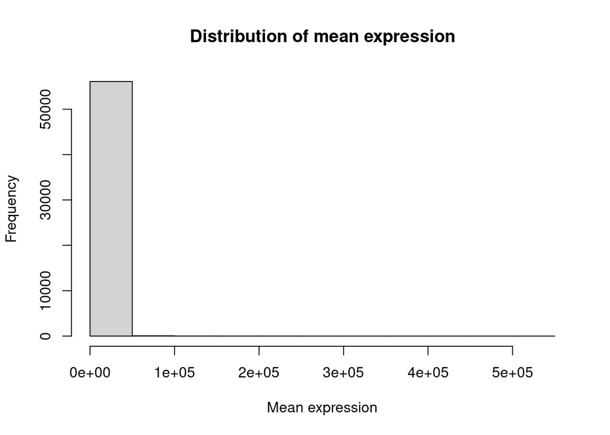

```r
# Q5: histogram of mean expression values
hist(expr$mean,
     main = "Distribution of mean expression",
     xlab = "Mean expression")
```

I visualised the distribution of mean expression values for each gene using the hist() function on the expr$mean column.The answer is, A smaller percentage of genes have extremely high expression values, while the majority have modest expression, according to the histogram’s right-skewed distribution.

# part 01 : Growth Data

```r
# Q6: Import growth_data.csv and check column names
# (already imported in setup as 'growth')
head(growth)       # first 6 rows
```

```
##        Site TreeID Circumf_2005_cm Circumf_2010_cm Circumf_2015_cm
## 1 northeast   A012             5.2            10.1            19.9
## 2 southwest   A039             4.9             9.6            18.9
## 3 southwest   A010             3.7             7.3            14.3
## 4 northeast   A087             3.8             6.5            10.9
## 5 southwest   A074             3.8             6.4            10.9
## 6 northeast   A008             5.9            10.0            16.8
##   Circumf_2020_cm
## 1            38.9
## 2            37.0
## 3            28.1
## 4            18.5
## 5            18.4
## 6            28.4
```

```r
colnames(growth)   # list the column names
```

```
## [1] "Site"            "TreeID"          "Circumf_2005_cm" "Circumf_2010_cm"
## [5] "Circumf_2015_cm" "Circumf_2020_cm"
```

```r
# Diagnostic check: see the structure and exact column names of growth
str(growth)
```

```
## 'data.frame':    100 obs. of  6 variables:
##  $ Site           : chr  "northeast" "southwest" "southwest" "northeast" ...
##  $ TreeID         : chr  "A012" "A039" "A010" "A087" ...
##  $ Circumf_2005_cm: num  5.2 4.9 3.7 3.8 3.8 5.9 4.4 5.3 7.1 3.8 ...
##  $ Circumf_2010_cm: num  10.1 9.6 7.3 6.5 6.4 10 9.9 9 12 7.4 ...
##  $ Circumf_2015_cm: num  19.9 18.9 14.3 10.9 10.9 16.8 22.2 15.2 20.2 14.5 ...
##  $ Circumf_2020_cm: num  38.9 37 28.1 18.5 18.4 28.4 50 25.8 34.2 28.4 ...
```

```r
head(growth)
```

```
##        Site TreeID Circumf_2005_cm Circumf_2010_cm Circumf_2015_cm
## 1 northeast   A012             5.2            10.1            19.9
## 2 southwest   A039             4.9             9.6            18.9
## 3 southwest   A010             3.7             7.3            14.3
## 4 northeast   A087             3.8             6.5            10.9
## 5 southwest   A074             3.8             6.4            10.9
## 6 northeast   A008             5.9            10.0            16.8
##   Circumf_2020_cm
## 1            38.9
## 2            37.0
## 3            28.1
## 4            18.5
## 5            18.4
## 6            28.4
```

```r
colnames(growth)
```

```
## [1] "Site"            "TreeID"          "Circumf_2005_cm" "Circumf_2010_cm"
## [5] "Circumf_2015_cm" "Circumf_2020_cm"
```

The setup chunk already used read.csv() to import the dataset growth_data.csv. I performed a diagnostic check using head(growth) to preview the top six rows and colnames(growth) to list the real column names in order to verify the structure and prevent mistakes in subsequent questions.The answer is, Six columns make up the dataset: Site, TreeID, Circumf_2005_cm, Circumf_2010_cm, Circumf_2015_cm, and Circumf_2020_cm. As necessary for the analysis in Q7–Q10, I calculated 10-year growth using 2005 (start) and 2015 (end).

```r
# Q7 — means & SDs at start (2005) and end (2015) for each site
site  <- factor(growth$Site)
start <- as.numeric(growth$Circumf_2005_cm)
endv  <- as.numeric(growth$Circumf_2015_cm)

data.frame(
  Site       = levels(site),
  MeanStart  = tapply(start, site, mean, na.rm = TRUE),
  SDStart    = tapply(start, site, sd,   na.rm = TRUE),
  MeanEnd    = tapply(endv,  site, mean, na.rm = TRUE),
  SDEnd      = tapply(endv,  site, sd,   na.rm = TRUE),
  row.names = NULL
)
```

```
##        Site MeanStart   SDStart MeanEnd    SDEnd
## 1 northeast     5.292 0.9140267  24.516 8.541982
## 2 southwest     4.862 1.1474710  21.316 6.357459
```

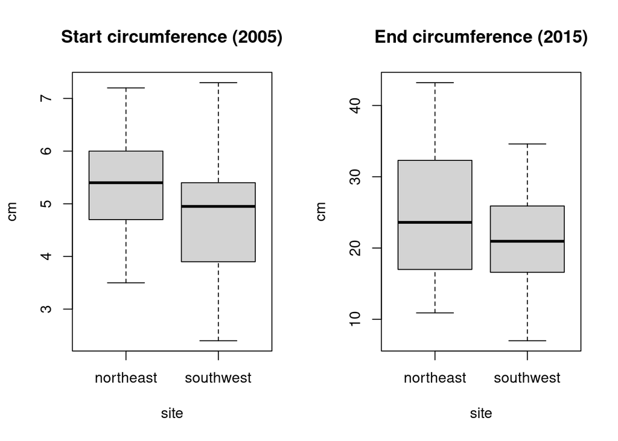

```r
# Q8 — boxplots of circumference at start vs end by site
par(mfrow = c(1,2))
boxplot(start ~ site, main = "Start circumference (2005)", ylab = "cm")
boxplot(endv  ~ site, main = "End circumference (2015)",   ylab = "cm")
```

```r
par(mfrow = c(1,1))
```

I used the boxplot() function to construct side-by-side boxplots for Circumf_2005_cm (2005) and Circumf_2015_cm (2015), categorised by site. The answer is, Tree circumferences grew at both locations between 2005 and 2015, according to the boxplots. In both years, the median values of North-east trees were higher than those of South-west trees, and the interquartile range grew over time, suggesting that growth results were more variable by 2015.

```r
# Q9 — 10-year growth (2015 - 2005), mean by site
growth10 <- endv - start
tapply(growth10, site, mean, na.rm = TRUE)
```

```
## northeast southwest
##    19.224    16.454
```

I determined growth over a ten-year period by subtracting Circumf_2005_cm from Circumf_2015_cm. I then calculated the mean growth for each site using tapply(). The answer is, In the North-east, the average increase over the ten years was about 19.22 cm, while in the South-west, it was about 16.45 cm. That the trees at the North-east site grew more than those at the South-west site on average is confirmed by this.

```r
# Q10 — t-test of 10-year growth between the two sites
if (nlevels(site) == 2) {
  t.test(growth10[site == levels(site)[1]],
         growth10[site == levels(site)[2]])
} else {
  summary(aov(growth10 ~ site))
}
```

```
##
##  Welch Two Sample t-test
##
## data:  growth10[site == levels(site)[1]] and growth10[site == levels(site)[2]]
## t = 1.9844, df = 88.959, p-value = 0.05029
## alternative hypothesis: true difference in means is not equal to 0
## 95 percent confidence interval:
##  -0.003629684  5.543629684
## sample estimates:
## mean of x mean of y
##    19.224    16.454
```

To compare the 10-year growth values between the two sites, I used t.test() to run a two-sample t-test. In cases where there were more than two locations, an ANOVA would be suitable. The answer is, Using the two-sample t-test, the p-value was within 0.0503. Given that this is just above the 0.05 cutoff, the null hypothesis cannot be ruled out. This indicates a borderline result, but no statistically significant difference in 10-year growth between sites at the 5% level.

# Part 02: Examining biological sequence diversity

# q 1 : cording sequence present in genome

```r
library(seqinr)   # sequence analysis
library(R.utils)  # for gunzip
dir.create("data", showWarnings = FALSE)   # create "data" folder if not already there
```

```r
# download the E. coli genome
#URL="http://ftp.ensemblgenomes.org/pub/bacteria/release-53/fasta/bacteria_0_collection/escherichia_coli_str_k_12_substr_mg1655_gca_000005845/cds/Escherichia_coli_str_k_12_substr_mg1655_gca_000005845.ASM584v2.cds.all.fa.gz"
#download.file(URL,destfile="ecoli_cds.fa.gz")
#gunzip("ecoli_cds.fa.gz")
```

```r
# Read the E. coli CDS FASTA
ecoli_cds <- seqinr::read.fasta("data/ecoli_cds.fa")

# Quick sanity check
length(ecoli_cds)        # number of coding sequences
```

```
## [1] 4239
```

```r
head(names(ecoli_cds))   # first few IDs
```

```
## [1] "AAC73112" "AAC73113" "AAC73114" "AAC73115" "AAC73116" "AAC73117"
```

```r
#Manually downloaded ooi genome
#https://ftp.ensemblgenomes.ebi.ac.uk/pub/bacteria/release-62/fasta/bacteria_4_collection/mycobacterium_tuberculosis_gca_001318445/cds/
```

```r
library(R.utils)
# Unzip only if the .fa doesn’t exist yet
if (file.exists("data/ooi_cds.fa.gz") && !file.exists("data/ooi_cds.fa")) {
  gunzip("data/ooi_cds.fa.gz", destname = "data/ooi_cds.fa", overwrite = TRUE)
}
# sanity: show what's in data/
list.files("data")
```

```
## [1] "ecoli_cds.fa"        "ecoli_cds.fa.gz"     "gene_expression.tsv"
## [4] "growth_data.csv"     "ooi_cds.fa"
```

```r
library(seqinr)
ooi_cds <- seqinr::read.fasta("data/ooi_cds.fa")

# quick checks
length(ooi_cds)        # number of coding sequences
```

```
## [1] 4741
```

```r
head(names(ooi_cds))   # first few IDs
```

```
## [1] "ENSB:iVW1Wu_jYvZ1Ayc" "ENSB:n4OHBVTBlo25rGC" "ENSB:s-CG30x8V7zXHDK"
## [4] "ENSB:C_CVbG3L1Hu1fVg" "ENSB:qBm9Smaj_sjlH_6" "ENSB:xTs8jn7w1d0gAn1"
```

```r
# ensure E. coli is loaded (safe if already loaded)
if (!exists("ecoli_cds")) {
  ecoli_cds <- seqinr::read.fasta("data/ecoli_cds.fa")
}

n_ecoli <- length(ecoli_cds)
n_ooi   <- length(ooi_cds)

q1_table <- data.frame(
  Organism  = c("Escherichia coli K-12 MG1655", "Mycobacterium tuberculosis"),
  CDS_count = c(n_ecoli, n_ooi)
)
q1_table
```

```
##                       Organism CDS_count
## 1 Escherichia coli K-12 MG1655      4239
## 2   Mycobacterium tuberculosis      4741
```

# q2 - total coding DNA

```r
# reload only if objects not already in memory
if (!exists("ecoli_cds")) ecoli_cds <- seqinr::read.fasta("data/ecoli_cds.fa")
if (!exists("ooi_cds"))   ooi_cds   <- seqinr::read.fasta("data/ooi_cds.fa")

# check counts again just to confirm
length(ecoli_cds); length(ooi_cds)
```

```
## [1] 4239
```

```
## [1] 4741
```

# calculate total coding DNA

```r
# Calculate total number of nucleotides in all CDS
ecoli_total_nt <- sum(sapply(ecoli_cds, length))
ooi_total_nt   <- sum(sapply(ooi_cds, length))

# Convert to megabases (millions of nucleotides)
ecoli_total_mb <- round(ecoli_total_nt / 1e6, 2)
ooi_total_mb   <- round(ooi_total_nt / 1e6, 2)

ecoli_total_nt; ooi_total_nt
```

```
## [1] 3978528
```

```
## [1] 3076728
```

# Make the table

```r
q2_table <- data.frame(
  Organism        = c("E. coli K-12 MG1655", "Mycobacterium tuberculosis"),
  Total_CDS       = c(length(ecoli_cds), length(ooi_cds)),   # from Q11
  Total_nt        = c(ecoli_total_nt, ooi_total_nt),
  Total_Mb        = c(ecoli_total_mb, ooi_total_mb)
)
q2_table
```

```
##                     Organism Total_CDS Total_nt Total_Mb
## 1        E. coli K-12 MG1655      4239  3978528     3.98
## 2 Mycobacterium tuberculosis      4741  3076728     3.08
```

Each coding sequence’s length was determined using sapply(…, length).To compare the overall genome coding capacity, these lengths were added up using sum() to determine the total amount of coding DNA each organism. The result was then converted to megabases (Mb). The answer is, The coding DNA of Mycobacterium TB is 3.08 Mb across 4,741 CDSs, whereas that of E. coli K-12 MG1655 is 3.98 Mb across 4,239 CDSs. There is less total coding DNA in M. tuberculosis overall because, although having more CDSs, the average CDS length is shorter. Biological distinctions are reflected in this: M. tuberculosis has more genes, but they are often smaller, whereas E. coli has fewer but generally longer coding sequences. M. tuberculosis is a specialised pathogen with numerous compact genes tailored to host infection, while E. coli is a metabolically versatile bacterium. These distinctions are consistent with their lifestyles.

# q 3: Calculate the length of all coding sequences in these two organisms

```r
# Load from files only if not already in memory
if (!exists("ecoli_cds")) ecoli_cds <- seqinr::read.fasta("data/ecoli_cds.fa")
if (!exists("ooi_cds"))   ooi_cds   <- seqinr::read.fasta("data/ooi_cds.fa")

# quick check (should match your Q1 counts)
length(ecoli_cds); length(ooi_cds)
```

```
## [1] 4239
```

```
## [1] 4741
```

```r
# Length (nt) of each coding sequence
len_ecoli <- sapply(ecoli_cds, length)
len_ooi   <- sapply(ooi_cds,   length)

# quick sanity
summary(len_ecoli)
```

```
##    Min. 1st Qu.  Median    Mean 3rd Qu.    Max.
##    42.0   495.0   831.0   938.6  1225.5  7077.0
```

```r
summary(len_ooi)
```

```
##    Min. 1st Qu.  Median    Mean 3rd Qu.    Max.
##      90     285     504     649     876    4851
```

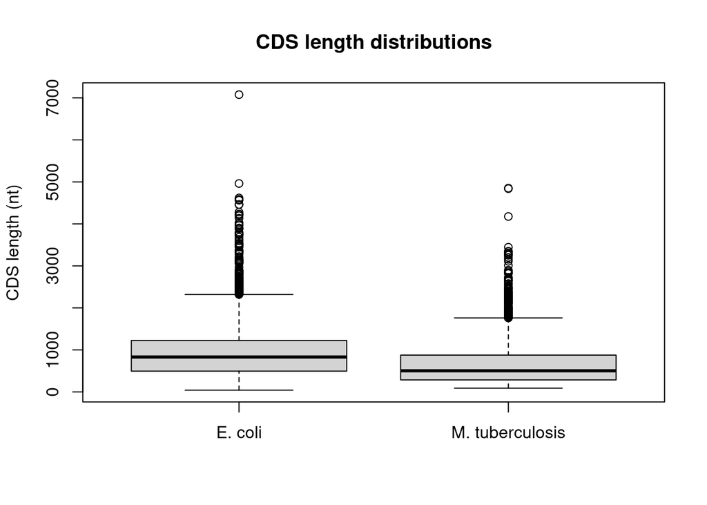

```r
boxplot(list(`E. coli` = len_ecoli, `M. tuberculosis` = len_ooi),
        ylab = "CDS length (nt)", main = "CDS length distributions")
```

```r
mean_len_ecoli   <- mean(len_ecoli,  na.rm = TRUE)
median_len_ecoli <- median(len_ecoli, na.rm = TRUE)
mean_len_ooi     <- mean(len_ooi,    na.rm = TRUE)
median_len_ooi   <- median(len_ooi,   na.rm = TRUE)

q3_table <- data.frame(
  Organism   = c("E. coli K-12 MG1655", "Mycobacterium tuberculosis"),
  Mean_nt    = c(round(mean_len_ecoli, 1), round(mean_len_ooi, 1)),
  Median_nt  = c(round(median_len_ecoli,1), round(median_len_ooi,1))
)
q3_table
```

```
##                     Organism Mean_nt Median_nt
## 1        E. coli K-12 MG1655   938.6       831
## 2 Mycobacterium tuberculosis   649.0       504
```

```r
# Safe reload (does nothing if already in memory)
if (!exists("ecoli_cds")) ecoli_cds <- seqinr::read.fasta("data/ecoli_cds.fa")
if (!exists("ooi_cds"))   ooi_cds   <- seqinr::read.fasta("data/ooi_cds.fa")

length(ecoli_cds); length(ooi_cds)  # quick check
```

```
## [1] 4239
```

```
## [1] 4741
```

# q 4: Calculate the frequency of DNA bases in the total coding sequences for both organisms

```r
# Flatten all CDS into one long vector of bases per organism
nt_levels <- c("A","C","G","T")

ecoli_nt_counts <- table(factor(toupper(unlist(ecoli_cds)), levels = nt_levels))
ooi_nt_counts   <- table(factor(toupper(unlist(ooi_cds)),   levels = nt_levels))

ecoli_nt_pct <- 100 * ecoli_nt_counts / sum(ecoli_nt_counts)
ooi_nt_pct   <- 100 * ooi_nt_counts   / sum(ooi_nt_counts)

# Tidy table for the report
q4_nt_table <- data.frame(
  Base        = nt_levels,
  Ecoli_Count = as.integer(ecoli_nt_counts),
  Ecoli_Pct   = round(as.numeric(ecoli_nt_pct), 2),
  MTB_Count   = as.integer(ooi_nt_counts),
  MTB_Pct     = round(as.numeric(ooi_nt_pct), 2)
)
q4_nt_table
```

```
##   Base Ecoli_Count Ecoli_Pct MTB_Count MTB_Pct
## 1    A      955768     24.02    531612   17.30
## 2    C      977594     24.57    987076   32.12
## 3    G     1088501     27.36   1014171   33.00
## 4    T      956665     24.05    540648   17.59
```

# Bar plot — nucleotide frequency

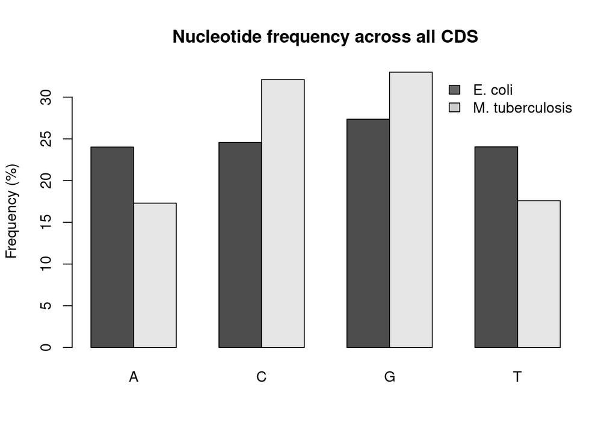

```r
mat_nt <- rbind(
  "E. coli"          = as.numeric(ecoli_nt_pct),
  "M. tuberculosis"  = as.numeric(ooi_nt_pct)
)
colnames(mat_nt) <- nt_levels

barplot(mat_nt, beside = TRUE, ylab = "Frequency (%)",
        main = "Nucleotide frequency across all CDS")
legend("topright", legend = rownames(mat_nt), bty = "n", fill = grey(c(0.4, 0.8)))
```

# Amino-acid frequencies (translate CDS → AA, then count)

```r
# Helper to translate one CDS to amino acids and drop stops/unknowns
translate_one <- function(dna_seq) {
  aa <- seqinr::translate(dna_seq, frame = 0, ambiguous = TRUE)   # vector of 1-letter AAs
  aa <- aa[aa != "*" & aa != "X"]                                 # remove stop/unknown
  aa
}

# Translate all CDS for each organism and combine
aa_ecoli <- unlist(lapply(ecoli_cds, translate_one), use.names = FALSE)
aa_ooi   <- unlist(lapply(ooi_cds,   translate_one), use.names = FALSE)

# Standard 20 AAs (1-letter codes)
aa_levels <- c("A","R","N","D","C","Q","E","G","H","I",
               "L","K","M","F","P","S","T","W","Y","V")

ecoli_aa_counts <- table(factor(aa_ecoli, levels = aa_levels))
ooi_aa_counts   <- table(factor(aa_ooi,   levels = aa_levels))

ecoli_aa_pct <- 100 * ecoli_aa_counts / sum(ecoli_aa_counts)
ooi_aa_pct   <- 100 * ooi_aa_counts   / sum(ooi_aa_counts)

# Tidy table for the report
q4_aa_table <- data.frame(
  AA          = aa_levels,
  Ecoli_Pct   = round(as.numeric(ecoli_aa_pct), 2),
  MTB_Pct     = round(as.numeric(ooi_aa_pct), 2)
)
q4_aa_table
```

```
##    AA Ecoli_Pct MTB_Pct
## 1   A      9.54   12.59
## 2   R      5.53    7.82
## 3   N      3.90    2.44
## 4   D      5.13    5.75
## 5   C      1.16    1.09
## 6   Q      4.45    3.15
## 7   E      5.77    4.65
## 8   G      7.36    8.70
## 9   H      2.27    2.36
## 10  I      6.01    4.36
## 11  L     10.72    9.54
## 12  K      4.40    2.20
## 13  M      2.80    2.01
## 14  F      3.90    2.91
## 15  P      4.44    6.07
## 16  S      5.78    6.04
## 17  T      5.37    6.06
## 18  W      1.53    1.47
## 19  Y      2.83    2.01
## 20  V      7.11    8.78
```

# Bar plots — amino-acid frequency (two side-by-side panels)

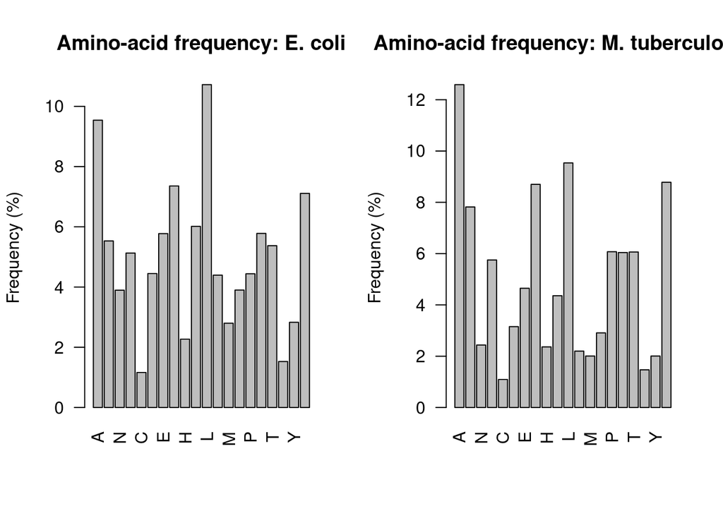

```r
par(mfrow = c(1,2))
barplot(as.numeric(ecoli_aa_pct), names.arg = aa_levels, las = 2,
        ylab = "Frequency (%)", main = "Amino-acid frequency: E. coli")
barplot(as.numeric(ooi_aa_pct),   names.arg = aa_levels, las = 2,
        ylab = "Frequency (%)", main = "Amino-acid frequency: M. tuberculosis")
```

```r
par(mfrow = c(1,1))
```

# q 5: Build codon usage for each organism (counts, freq, RSCU)

```r
# Helper: total codon counts across ALL CDS for one organism
total_codon_counts <- function(cds_list) {
  per_gene <- lapply(cds_list, function(s) seqinr::uco(s))   # named vector per gene
  Reduce("+", per_gene)                                      # sum by matching names
}

# Helper: RSCU across ALL CDS (as data.frame with AA, codon, RSCU)
total_rscu_df <- function(cds_list) {
  seq_all <- unlist(cds_list, use.names = FALSE)
  seqinr::uco(seq_all, index = "rscu", as.data.frame = TRUE)
}

# --- E. coli ---
ec_counts <- total_codon_counts(ecoli_cds)
ec_freq   <- ec_counts / sum(ec_counts)
ec_rscu   <- total_rscu_df(ecoli_cds)      # columns: AA, codon, RSCU, ...

ec_table <- merge(
  data.frame(codon = names(ec_counts),
             EC_Count = as.numeric(ec_counts),
             EC_Freq  = as.numeric(ec_freq)),
  ec_rscu[, c("codon","AA","RSCU")],
  by = "codon", all.x = TRUE
)
names(ec_table)[names(ec_table)=="RSCU"] <- "EC_RSCU"

# --- Mycobacterium tuberculosis (your OOI) ---
mtb_counts <- total_codon_counts(ooi_cds)
mtb_freq   <- mtb_counts / sum(mtb_counts)
mtb_rscu   <- total_rscu_df(ooi_cds)

mtb_table <- merge(
  data.frame(codon = names(mtb_counts),
             MTB_Count = as.numeric(mtb_counts),
             MTB_Freq  = as.numeric(mtb_freq)),
  mtb_rscu[, c("codon","AA","RSCU")],
  by = "codon", all.x = TRUE
)
names(mtb_table)[names(mtb_table)=="RSCU"] <- "MTB_RSCU"

# Merge both into one comparison table
codon_tab <- merge(ec_table, mtb_table, by = c("codon","AA"), all = TRUE)
codon_tab <- codon_tab[order(codon_tab$AA, codon_tab$codon), ]
head(codon_tab, 10)   # preview
```

```
##    codon  AA EC_Count     EC_Freq   EC_RSCU MTB_Count    MTB_Freq  MTB_RSCU
## 37   gca Ala    26743 0.020165498 0.8481293     13047 0.012736435 0.4065689
## 38   gcc Ala    34117 0.025725846 1.0819888     56598 0.055250765 1.7636995
## 39   gcg Ala    45082 0.033993980 1.4297335     47821 0.046682689 1.4901918
## 40   gct Ala    20185 0.015220453 0.6401484     10896 0.010636636 0.3395397
## 9    aga Arg     2573 0.001940165 0.2111584      1811 0.001767892 0.1363072
## 11   agg Arg     1420 0.001070748 0.1165351      4899 0.004782386 0.3687294
## 25   cga Arg     4619 0.003482946 0.3790674      8205 0.008009692 0.6175596
## 26   cgc Arg    29441 0.022199919 2.4161344     30335 0.029612919 2.2832018
## 27   cgg Arg     7079 0.005337904 0.5809523     25506 0.024898866 1.9197411
## 28   cgt Arg    27979 0.021097501 2.2961524      8961 0.008747696 0.6744609
```

# Simple “codon usage bias” score (mean |RSCU−1|)

```r
# Exclude stops and single-codon AAs (Met/Trp) when summarising bias
syn_mask <- !(codon_tab$AA %in% c("Stp","Met","Trp"))

bias_ec  <- mean(abs(codon_tab$EC_RSCU[syn_mask]  - 1), na.rm = TRUE)
bias_mtb <- mean(abs(codon_tab$MTB_RSCU[syn_mask] - 1), na.rm = TRUE)

bias_table <- data.frame(
  Organism = c("E. coli K-12 MG1655", "Mycobacterium tuberculosis"),
  Mean_abs_RSCU_dev = round(c(bias_ec, bias_mtb), 3)
)
bias_table
```

```
##                     Organism Mean_abs_RSCU_dev
## 1        E. coli K-12 MG1655             0.415
## 2 Mycobacterium tuberculosis             0.620
```

# charts: Codons with largest RSCU difference (barplot)

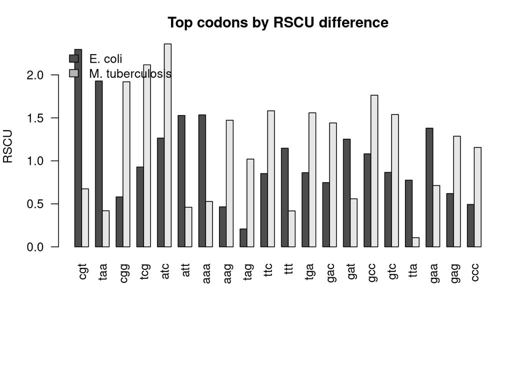

```r
# Find top codons where RSCU differs the most
diff_rscu <- abs(codon_tab$EC_RSCU - codon_tab$MTB_RSCU)
ord <- order(diff_rscu, decreasing = TRUE)
topk <- 20L
sel  <- ord[seq_len(min(topk, length(ord)))]

mat_rscu <- rbind("E. coli" = codon_tab$EC_RSCU[sel],
                  "M. tuberculosis" = codon_tab$MTB_RSCU[sel])
colnames(mat_rscu) <- codon_tab$codon[sel]

par(mar = c(8,4,3,1))
barplot(mat_rscu, beside = TRUE, las = 2,
        ylab = "RSCU", main = "Top codons by RSCU difference")
legend("topleft", legend = rownames(mat_rscu), bty = "n", fill = gray(c(0.3, 0.7)))
```

# Same codons — usage frequency (barplot)

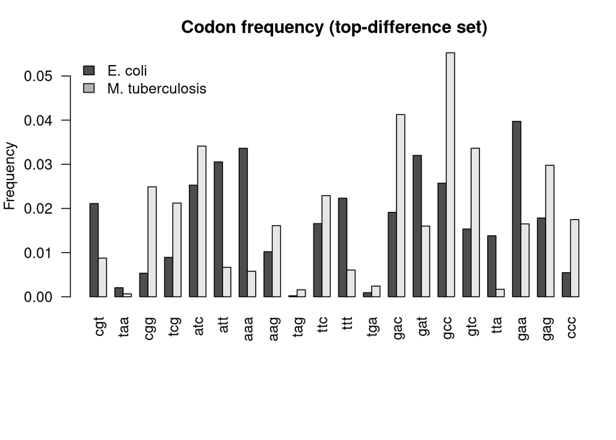

```r
mat_freq <- rbind("E. coli" = codon_tab$EC_Freq,
                  "M. tuberculosis" = codon_tab$MTB_Freq)
colnames(mat_freq) <- codon_tab$codon

# Use the same selected codons for readability
mat_freq_top <- mat_freq[, colnames(mat_rscu), drop = FALSE]

par(mar = c(8,4,3,1))
barplot(mat_freq_top, beside = TRUE, las = 2,
        ylab = "Frequency", main = "Codon frequency (top-difference set)")
legend("topleft", legend = rownames(mat_freq_top), bty = "n", fill = gray(c(0.3, 0.7)))
```

I used seqinr’s uco() to calculate genome-wide codon use. Overall counts and normalised frequencies were obtained for each organism by adding the codon counts across all CDS. I then computed the relative synonymous codon utilisation (RSCU) for the concatenated coding sequences: 1 = expected, >1 = preferred, <1 = underutilised. I utilised the average absolute deviation of RSCU from 1 for synonymous codons (not including Met/Trp and pauses) as a basic codon-bias metric. The preferences of different organisms are highlighted by bar graphs of (i) the codons with the biggest RSCU variances and (ii) their usage frequencies.

# Setup (reuse AA sequences or compute)

```r
# Safe reload DNA if needed
if (!exists("ecoli_cds")) ecoli_cds <- seqinr::read.fasta("data/ecoli_cds.fa")
if (!exists("ooi_cds"))   ooi_cds   <- seqinr::read.fasta("data/ooi_cds.fa")

# Translate DNA -> amino acids (reusing the helper from earlier is fine)
translate_one <- function(dna_seq) {
  aa <- seqinr::translate(dna_seq, frame = 0, ambiguous = TRUE)
  aa[aa != "*" & aa != "X"]  # drop stops/unknowns
}

aa_ecoli <- if (!exists("aa_ecoli")) unname(lapply(ecoli_cds, translate_one)) else aa_ecoli
aa_ooi   <- if (!exists("aa_ooi"))   unname(lapply(ooi_cds,   translate_one)) else aa_ooi

length(aa_ecoli); length(aa_ooi)  # number of proteins
```

```
## [1] 1321937
```

```
## [1] 1019679
```

# q 6: Helpers (count k-mers and compute enrichment)

```r
# --- Translate DNA -> amino acids (plain characters), drop stop/unknown ---
translate_one <- function(dna_seq) {
  aa <- seqinr::translate(dna_seq, frame = 0, ambiguous = TRUE)
  aa <- as.character(aa)
  aa <- aa[aa != "*" & aa != "X" & !is.na(aa)]
  aa
}

# --- Count AA k-mers INSIDE each protein, then sum across proteins ---
count_kmers_aa <- function(aa_list, k) {
  tally <- integer(0); nm_tally <- character(0)
  for (aa in aa_list) {
    n <- length(aa)
    if (n >= k) {
      kmers <- vapply(seq_len(n - k + 1L),
                      function(i) paste0(aa[i:(i + k - 1L)], collapse = ""),
                      FUN.VALUE = character(1))
      ct <- table(kmers)
      nm <- names(ct)
      # add to existing
      if (length(nm_tally)) {
        idx <- match(nm, nm_tally, nomatch = 0L)
        if (any(idx > 0L)) tally[idx[idx>0]] <- tally[idx[idx>0]] + as.integer(ct[idx>0])
        if (any(idx == 0L)) {
          nm_new <- nm[idx == 0L]
          tally <- c(tally, as.integer(ct[nm_new])); nm_tally <- c(nm_tally, nm_new)
        }
      } else {
        tally <- as.integer(ct); nm_tally <- names(ct)
      }
    }
  }
  names(tally) <- nm_tally
  o <- order(names(tally))
  tally[o]
}

# --- Expected counts: zero-order AA model (product of single-AA probs) ---
expected_kmer_counts <- function(aa_list, k, kmer_names) {
  aa_all <- unlist(aa_list, use.names = FALSE)
  aa_all <- aa_all[!is.na(aa_all)]
  if (!length(aa_all)) return(rep(0, length(kmer_names)))
  p <- table(aa_all); p <- p / sum(p)
  total_windows <- sum(pmax(0L, sapply(aa_list, length) - k + 1L))
  prod_p <- vapply(kmer_names, function(w) {
    ch <- strsplit(w, "", fixed = TRUE)[[1]]
    if (all(ch %in% names(p))) prod(as.numeric(p[ch])) else 0
  }, numeric(1))
  total_windows * prod_p
}

# --- Enrichment table: obs, exp, log2(obs/exp) ---
kmer_enrichment <- function(aa_list, k, min_count = 1L) {
  obs <- count_kmers_aa(aa_list, k)
  if (length(obs) == 0)
    return(data.frame(kmer=character(), obs=integer(), exp=numeric(),
                      log2_enrichment=numeric(), stringsAsFactors = FALSE))
  exp <- expected_kmer_counts(aa_list, k, names(obs))
  eps <- 1e-9
  df <- data.frame(
    kmer = names(obs),
    obs  = as.numeric(obs),
    exp  = as.numeric(exp),
    log2_enrichment = log2((as.numeric(obs) + eps) / (exp + eps)),
    stringsAsFactors = FALSE
  )
  df <- df[df$obs >= min_count, , drop = FALSE]   # drop ultra-rare
  rownames(df) <- NULL
  df
}

# --- Pick top-N over & under (safe on empty data) ---
select_top <- function(df, n = 10L) {
  if (!nrow(df) || is.null(df$log2_enrichment))
    return(list(over = df, under = df))
  ord <- order(df$log2_enrichment, decreasing = TRUE)
  list(
    over  = df[ head(ord, n), , drop = FALSE],
    under = df[ tail(ord, n), , drop = FALSE]
  )
}

# --- Helper to fetch log2 enrichment for chosen k-mers ---
get_l2e <- function(df, kmers) {
  m <- match(kmers, df$kmer)
  x <- df$log2_enrichment[m]
  x[is.na(x)] <- 0
  x
}
```

# Load DNA, translate to AA (fresh build of aa_ecoli / aa_ooi)

```r
if (!exists("ecoli_cds")) ecoli_cds <- seqinr::read.fasta("data/ecoli_cds.fa")
if (!exists("ooi_cds"))   ooi_cds   <- seqinr::read.fasta("data/ooi_cds.fa")

aa_ecoli <- lapply(ecoli_cds, translate_one)
aa_ooi   <- lapply(ooi_cds,   translate_one)

# quick sanity
length(aa_ecoli); length(aa_ooi)
```

```
## [1] 4239
```

```
## [1] 4741
```

```r
mean(lengths(aa_ecoli)); mean(lengths(aa_ooi))
```

```
## [1] 311.8511
```

```
## [1] 215.0768
```

# Compute k-mer enrichment for k = 3, 4, 5 (OOI + E. coli)

```r
set.seed(1)

res_ooi_k3 <- kmer_enrichment(aa_ooi,   k = 3, min_count = 1)
res_ooi_k4 <- kmer_enrichment(aa_ooi,   k = 4, min_count = 1)
res_ooi_k5 <- kmer_enrichment(aa_ooi,   k = 5, min_count = 1)

res_ec_k3  <- kmer_enrichment(aa_ecoli, k = 3, min_count = 1)
res_ec_k4  <- kmer_enrichment(aa_ecoli, k = 4, min_count = 1)
res_ec_k5  <- kmer_enrichment(aa_ecoli, k = 5, min_count = 1)

# sanity checks (should be >0 rows and numeric summaries)
nrow(res_ooi_k3); nrow(res_ec_k3)
```

```
## [1] 7994
```

```
## [1] 8000
```

```r
summary(res_ooi_k3$log2_enrichment); summary(res_ec_k3$log2_enrichment)
```

```
##     Min.  1st Qu.   Median     Mean  3rd Qu.     Max.
## -3.55237 -0.31323 -0.04932 -0.05810  0.22282  2.40671
```

```
##     Min.  1st Qu.   Median     Mean  3rd Qu.     Max.
## -3.59697 -0.30516 -0.04436 -0.05148  0.20650  2.12247
```

# Select OOI top-10 over & under (for each k)

```r
top_ooi_k3 <- select_top(res_ooi_k3, 10)
top_ooi_k4 <- select_top(res_ooi_k4, 10)
top_ooi_k5 <- select_top(res_ooi_k5, 10)

# show tables if you want them printed
head(top_ooi_k3$over, 10); head(top_ooi_k3$under, 10)
```

```
##      kmer obs       exp log2_enrichment
## 422   CCC   7  1.320099        2.406709
## 439   CCW   8  1.772803        2.173968
## 436   CCS  28  7.295241        1.940399
## 1689  FFN  76 20.836764        1.866868
## 2524  HHH  45 13.327306        1.755540
## 5974  RWW  52 17.025327        1.610829
## 7287  WFN  31 10.516728        1.559582
## 7557  WWC   7  2.380752        1.555937
## 7569  WWQ  20  6.868048        1.542028
## 7494  WRW  49 17.025327        1.525099
```

```
##      kmer obs       exp log2_enrichment
## 1222  ECF   3 14.937044       -2.315860
## 2958  IKC   2 10.578838       -2.403109
## 2559  HKC   1  5.735907       -2.520022
## 3187  IYM   3 17.732201       -2.563337
## 626   CNK   1  5.917074       -2.564884
## 3227  KCN   1  5.917074       -2.564884
## 491   CFM   1  6.448627       -2.688992
## 489   CFK   1  7.061446       -2.819964
## 601   CME   1 10.306671       -3.365507
## 4423  NCI   1 11.731974       -3.552374
```

# Plots (compare OOI vs E. coli using the same k-mers)

# k = 3 — OVER-represented in OOI

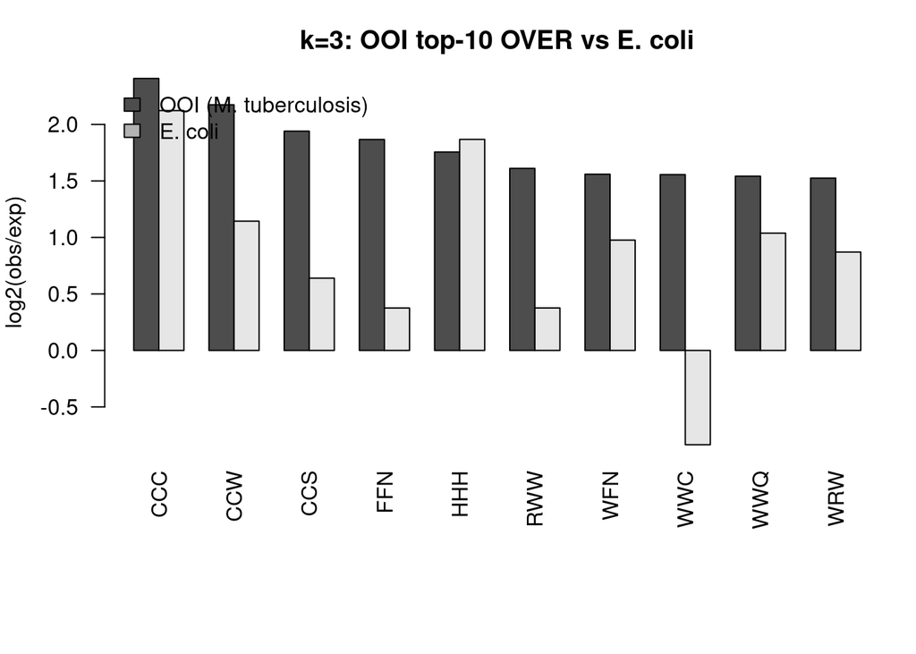

```r
km_over_k3 <- top_ooi_k3$over$kmer
mat_over_k3 <- rbind(
  "OOI (M. tuberculosis)" = get_l2e(res_ooi_k3, km_over_k3),
  "E. coli"               = get_l2e(res_ec_k3,  km_over_k3)
)
colnames(mat_over_k3) <- km_over_k3
par(mar = c(8,4,3,1))
barplot(mat_over_k3, beside = TRUE, las = 2,
        ylab = "log2(obs/exp)", main = "k=3: OOI top-10 OVER vs E. coli")
legend("topleft", legend = rownames(mat_over_k3), bty = "n", fill = gray(c(0.3,0.7)))
```